# Case Study: How Does a Bike-Share Navigate Speedy Success?

Abdulrahman E

2023-07-06

## Introduction

In 2016, A bike sharing company, Cyclistic, launched an offering. Since then, the program has grown to a fleet of 5,824 bicycles that are geotracked and locked into a network of 692 stations across chicago. Their marketing strategy depended on building general awareness and appealing to broad consumer segments. The customers who used the services are of two types: customers who purchase single-ride or full day passes; these are causal riders, and customers who purchase annual memberships are annual members. Although annual members are more profitable than casual riders, the director of marketing believes that increasing and maximizing the amount of annual members will be the key to future growth.

# Ask

### Business Task

The objective is to see how casual riders differ from annual members by pulling out rider data and analyzing it so that they can plan their marketing accordingly to grow their company.

# Prepare

### Data Preparation

Here is the link to the Datasets :https://divvy-tripdata.s3.amazonaws.com/index.html The data has been made available by Motivate International Inc. under this license: https://ride.divvybikes.com/data-license-agreement

The Datasets are appropriate and will help us carry on with the analysis. The Data has been collected from the past 12 months (June 2022 - May 2023 or June 2023). The Data has been divided into 12 files.

Each table consists of the following columns:

“ride_id” : the ID of the ride mixed with capital letters and numbers  
“rideable_type” : the type of bike used, either classic bike or electric bike “started_at” : the date and time the ride started “ended_at” : the date and time the ride ended “start_station_name”: the name of the start station “start_station_id” : the ID of the start station “end_station_name” : the name of the end station “end_station_id” : the ID of the end station “start_lat” : the start latitude “start_lng” : the start longitude “end_lat” : the end latitude “end_lng” : the end longitude “member_casual” : if the user is casual or a member

# Process

I initially chose “spreadsheets” to clean the data easily, but I discovered that it is not capable of taking too much data. I was able to upload some files (which were less than 100 MB), and was not able to upload others (because of the large amount of data). I decided not to use SQL because I have to pay money for more storage (to add a lot of data). I wanted to practice my skills on spreadsheets for cleaning, sorting, and filtering data, and performing calculations for newer data. I was left with one more option, which was R. With R, I was able to upload all of the datasets, and I was able to both see the data and clean it in a much easier manner. I was also able to perform calculations and visualizations easily too.

### Documentation of the Cleaning/Manipulating Process

Looking at the data…

The data that was not clean, organized, and listed in a consistent manner and left blank multiple times is from these columns:

start_station_name, start_station_id, end_station_name end_station_id

and I filled the empty cells with red color to indicate it is null.

I was also instructed to calculate the length of the ride by time (H:M:S) by subtracting the two time intervals, the day of the week by number (e.x. Saturday = 7), the maximum length of the ride by time, and the most often repeated day of the week. This is helpful to gain insights of the data. And I added these calculations into new columns

# Analyze

Because of the memory limitations of both spreadsheets and SQL, I decided to use R for the whole project. The first step was to install and open the library of the following packages.

```r
library(tidyverse)
library(lubridate)
library(ggplot2)
```

The second step was to create variables and assign csv files to them.

```r
June2022 <- read_csv("202206-divvy-tripdata.csv")
July2022 <- read_csv("202207-divvy-tripdata.csv")
Aug2022 <- read_csv("202208-divvy-tripdata.csv")
Sept2022 <- read_csv("202209-divvy-publictripdata.csv")
Oct2022 <- read_csv("202210-divvy-tripdata.csv")
Nov2022 <- read_csv("202211-divvy-tripdata.csv")
Dec2022 <- read_csv("202212-divvy-tripdata.csv")
Jan2023 <- read_csv("202301-divvy-tripdata.csv")
Feb2023 <- read_csv("202302-divvy-tripdata.csv")
March2023 <- read_csv("202303-divvy-tripdata.csv")
April2023 <- read_csv("202304-divvy-tripdata.csv")
May2023 <- read_csv("202305-divvy-tripdata.csv")
```

I did this for all 12 files, from June 2022 until May 2023, files of data for the past 12 months as instructed.

The third step was to check the column names of each table to check if they are the same so we can combine the tables into one table.

```r
colnames(June2022)
```

```
##  [1] "ride_id"            "rideable_type"      "started_at"
##  [4] "ended_at"           "start_station_name" "start_station_id"
##  [7] "end_station_name"   "end_station_id"     "start_lat"
## [10] "start_lng"          "end_lat"            "end_lng"
## [13] "member_casual"
```

```r
colnames(July2022)
```

```
##  [1] "ride_id"            "rideable_type"      "started_at"
##  [4] "ended_at"           "start_station_name" "start_station_id"
##  [7] "end_station_name"   "end_station_id"     "start_lat"
## [10] "start_lng"          "end_lat"            "end_lng"
## [13] "member_casual"
```

I did this for all 12 datasets, and they all have the same column names.

The fourth step was to convert ride_id and rideable_type (for all of the datasets) to character so that they can stack correctly

```r
June2022 <-  mutate(June2022, ride_id = as.character(ride_id)
                   ,rideable_type = as.character(rideable_type))
July2022 <-  mutate(July2022, ride_id = as.character(ride_id)
                   ,rideable_type = as.character(rideable_type))
Aug2022 <-  mutate(Aug2022, ride_id = as.character(ride_id)
                   ,rideable_type = as.character(rideable_type))
Sept2022 <-  mutate(Sept2022, ride_id = as.character(ride_id)
                     ,rideable_type = as.character(rideable_type))
Oct2022 <-  mutate(Oct2022, ride_id = as.character(ride_id)
                     ,rideable_type = as.character(rideable_type))
Nov2022 <-  mutate(Nov2022, ride_id = as.character(ride_id)
                   ,rideable_type = as.character(rideable_type))
Dec2022 <-  mutate(Dec2022, ride_id = as.character(ride_id)
                   ,rideable_type = as.character(rideable_type))
Jan2023 <-  mutate(Jan2023, ride_id = as.character(ride_id)
                   ,rideable_type = as.character(rideable_type))
Feb2023 <-  mutate(Feb2023, ride_id = as.character(ride_id)
                   ,rideable_type = as.character(rideable_type))
March2023 <-  mutate(March2023, ride_id = as.character(ride_id)
                     ,rideable_type = as.character(rideable_type))
April2023 <-  mutate(April2023, ride_id = as.character(ride_id)
                     ,rideable_type = as.character(rideable_type))
May2023 <-  mutate(May2023, ride_id = as.character(ride_id)
                   ,rideable_type = as.character(rideable_type))
```

After doing this for all of the datasets, I combined them into one variable/dataset, and named it twelvemonths.

```r
twelvemonths <- bind_rows(June2022, July2022, Aug2022, Sept2022, Oct2022, Nov2022, Dec2022, Jan2023, Feb2023, March2023, April2023, May2023)
```

Below is all the information about the dataset, twelvemonths, which includes the mean, median, maximum, and minimum of each column filled with numbers.

```r
summary(twelvemonths)
```

```
##    ride_id          rideable_type        started_at
##  Length:5829030     Length:5829030     Min.   :2022-06-01 00:00:04
##  Class :character   Class :character   1st Qu.:2022-07-27 14:54:51
##  Mode  :character   Mode  :character   Median :2022-09-23 07:56:12
##                                        Mean   :2022-10-28 01:02:13
##                                        3rd Qu.:2023-02-05 15:35:06
##                                        Max.   :2023-05-31 23:59:58
##
##     ended_at                   start_station_name start_station_id
##  Min.   :2022-06-01 00:02:38   Length:5829030     Length:5829030
##  1st Qu.:2022-07-27 15:16:15   Class :character   Class :character
##  Median :2022-09-23 08:14:32   Mode  :character   Mode  :character
##  Mean   :2022-10-28 01:20:55
##  3rd Qu.:2023-02-05 15:50:20
##  Max.   :2023-06-07 23:04:26
##
##  end_station_name   end_station_id       start_lat       start_lng
##  Length:5829030     Length:5829030     Min.   :41.64   Min.   :-87.87
##  Class :character   Class :character   1st Qu.:41.88   1st Qu.:-87.66
##  Mode  :character   Mode  :character   Median :41.90   Median :-87.64
##                                        Mean   :41.90   Mean   :-87.65
##                                        3rd Qu.:41.93   3rd Qu.:-87.63
##                                        Max.   :42.07   Max.   :-87.52
##
##     end_lat         end_lng       member_casual
##  Min.   : 0.00   Min.   :-88.11   Length:5829030
##  1st Qu.:41.88   1st Qu.:-87.66   Class :character
##  Median :41.90   Median :-87.64   Mode  :character
##  Mean   :41.90   Mean   :-87.65
##  3rd Qu.:41.93   3rd Qu.:-87.63
##  Max.   :42.37   Max.   :  0.00
##  NA's   :5961    NA's   :5961
```

The next step was to add columns into the Dataset, day of the week, month, and year. This is so we can analyze the data by days of the week.

```r
twelvemonths$date <- as.Date(twelvemonths$started_at) #The default format is yyyy-mm-dd
twelvemonths$month <- format(as.Date(twelvemonths$date), "%m")
twelvemonths$day <- format(as.Date(twelvemonths$date), "%d")
twelvemonths$year <- format(as.Date(twelvemonths$date), "%Y")
twelvemonths$day_of_week <- format(as.Date(twelvemonths$date), "%A")
```

Then I have to add a ride_length column to get the length of the ride by seconds.

```r
twelvemonths$ride_length <- difftime(twelvemonths$ended_at,twelvemonths$started_at)
```

Then to convert ride_length from factor to numeric so we can run calculations.

```r
is.factor(twelvemonths$ride_length)
```

```
## [1] FALSE
```

```r
twelvemonths$ride_length <- as.numeric(as.character(twelvemonths$ride_length))
is.numeric(twelvemonths$ride_length)
```

```
## [1] TRUE
```

Now let’s take a look at the Dataset by its information.

```r
summary(twelvemonths$ride_length)
```

```
##    Min. 1st Qu.  Median    Mean 3rd Qu.    Max.
## -621201     335     591    1123    1057 2483235
```

As I looked into the data, I found one problem which I did not find in the spreadsheets, and that is the existence of negative numbers in the ride_length. I had a feeling that it would not look good for the analysis. So I eliminated the negative numbers. I made another dataset called twelvemonths_positive, excluding all numbers in the ride_length that are less than zero.

```r
twelvemonths_positive <- twelvemonths[!(twelvemonths$ride_length<0),]
```

Now, if we pulled out the minimum value

```r
min(twelvemonths_positive$ride_length) #shortest ride
```

```
## [1] 0
```

It will come out as zero.

Let’s compare the mean, median, maximum, and minimum of the ride length for both members and casual users.

```r
aggregate(twelvemonths_positive$ride_length ~ twelvemonths_positive$member_casual, FUN = mean)
```

```
##   twelvemonths_positive$member_casual twelvemonths_positive$ride_length
## 1                              casual                         1692.5512
## 2                              member                          748.1938
```

```r
aggregate(twelvemonths_positive$ride_length ~ twelvemonths_positive$member_casual, FUN = median)
```

```
##   twelvemonths_positive$member_casual twelvemonths_positive$ride_length
## 1                              casual                               735
## 2                              member                               517
```

```r
aggregate(twelvemonths_positive$ride_length ~ twelvemonths_positive$member_casual, FUN = max)
```

```
##   twelvemonths_positive$member_casual twelvemonths_positive$ride_length
## 1                              casual                           2483235
## 2                              member                             93580
```

```r
aggregate(twelvemonths_positive$ride_length ~ twelvemonths_positive$member_casual, FUN = min)
```

```
##   twelvemonths_positive$member_casual twelvemonths_positive$ride_length
## 1                              casual                                 0
## 2                              member                                 0
```

Since the dataset is too large for us to plot (over 5 million rows), we will calculate the average ride duration to make the numbers and display easier to see. We will calculate the average ride duration for each day of the week for both casual riders and members.

Let’s see the average ride time by each day for members vs casual users.

```r
aggregate(twelvemonths_positive$ride_length ~ twelvemonths_positive$member_casual + twelvemonths_positive$day_of_week, FUN = mean)
```

```
##    twelvemonths_positive$member_casual twelvemonths_positive$day_of_week
## 1                               casual                            Friday
## 2                               member                            Friday
## 3                               casual                            Monday
## 4                               member                            Monday
## 5                               casual                          Saturday
## 6                               member                          Saturday
## 7                               casual                            Sunday
## 8                               member                            Sunday
## 9                               casual                          Thursday
## 10                              member                          Thursday
## 11                              casual                           Tuesday
## 12                              member                           Tuesday
## 13                              casual                         Wednesday
## 14                              member                         Wednesday
##    twelvemonths_positive$ride_length
## 1                          1641.6201
## 2                           740.5853
## 3                          1653.3675
## 4                           710.7680
## 5                          1924.6666
## 6                           834.7332
## 7                          2002.5709
## 8                           830.8878
## 9                          1462.1990
## 10                          721.9582
## 11                         1516.8989
## 12                          718.8808
## 13                         1436.5559
## 14                          714.8249
```

Let’s set the days of the week in order.

```r
twelvemonths_positive$day_of_week <- ordered(twelvemonths_positive$day_of_week, levels=c("Sunday", "Monday", "Tuesday", "Wednesday", "Thursday", "Friday", "Saturday"))
```

Now, display the data again, but in the set order of the days of the week.

```r
aggregate(twelvemonths_positive$ride_length ~ twelvemonths_positive$member_casual + twelvemonths_positive$day_of_week, FUN = mean)
```

```
##    twelvemonths_positive$member_casual twelvemonths_positive$day_of_week
## 1                               casual                            Sunday
## 2                               member                            Sunday
## 3                               casual                            Monday
## 4                               member                            Monday
## 5                               casual                           Tuesday
## 6                               member                           Tuesday
## 7                               casual                         Wednesday
## 8                               member                         Wednesday
## 9                               casual                          Thursday
## 10                              member                          Thursday
## 11                              casual                            Friday
## 12                              member                            Friday
## 13                              casual                          Saturday
## 14                              member                          Saturday
##    twelvemonths_positive$ride_length
## 1                          2002.5709
## 2                           830.8878
## 3                          1653.3675
## 4                           710.7680
## 5                          1516.8989
## 6                           718.8808
## 7                          1436.5559
## 8                           714.8249
## 9                          1462.1990
## 10                          721.9582
## 11                         1641.6201
## 12                          740.5853
## 13                         1924.6666
## 14                          834.7332
```

Let’s analyze ridership data by type and weekday

```r
twelvemonths_positive %>%
  mutate(weekday = wday(started_at, label = TRUE)) %>%  #creates weekday field using wday()
  group_by(member_casual, weekday) %>%  #groups by user type and weekday
  summarise(number_of_rides = n()                           #calculates the number of rides and average duration
            ,average_duration = mean(ride_length)) %>%      # calculates the average duration
  arrange(member_casual, weekday)    #sorts
```

```
## # A tibble: 14 × 4
## # Groups:   member_casual [2]
##    member_casual weekday number_of_rides average_duration
##    <chr>         <ord>             <int>            <dbl>
##  1 casual        Sun              375613            2003.
##  2 casual        Mon              257820            1653.
##  3 casual        Tue              270962            1517.
##  4 casual        Wed              291902            1437.
##  5 casual        Thu              313339            1462.
##  6 casual        Fri              346555            1642.
##  7 casual        Sat              455826            1925.
##  8 member        Sun              394535             831.
##  9 member        Mon              471393             711.
## 10 member        Tue              552529             719.
## 11 member        Wed              579333             715.
## 12 member        Thu              564900             722.
## 13 member        Fri              501463             741.
## 14 member        Sat              452748             835.
```

Let’s create a visualization (a bar graph will work for this)

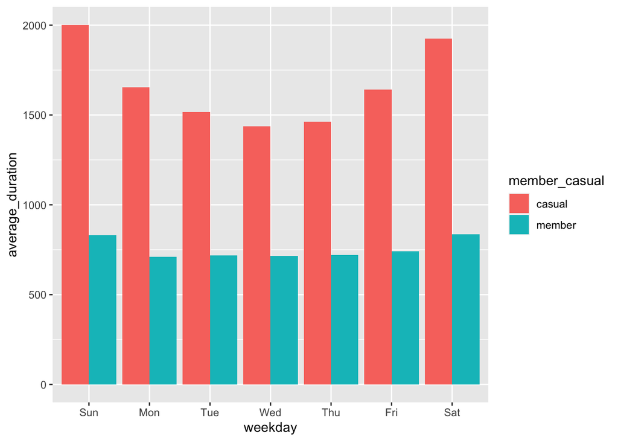

```r
twelvemonths_positive %>%
  mutate(weekday = wday(started_at, label = TRUE)) %>%
  group_by(member_casual, weekday) %>%
  summarise(number_of_rides = n()
            ,average_duration = mean(ride_length)) %>%
  arrange(member_casual, weekday)  %>%
  ggplot(aes(x = weekday, y = average_duration, fill = member_casual)) +
  geom_col(position = "dodge")
```

So what you see above is the bar graph, and I had to include a lot code only to be able to generate the graph along with the final calculations.

Here is another bar graph similar to the previous one, which was made using Tableau.

[figure not shown]

If the Tableau graph doesn’t display properly, use this link: https://public.tableau.com/app/profile/abdulrahman.elsaadawi/viz/CasualRidersandMembersComparisonbyAverage/Sheet1